# Age solutions

Harly Durbin

# Notes & questions

- BIF age of dam BW: 2, 3, 4, 5-9, >= 10
- When does a mean need to be included in the model??
- According to AAA guidelines: “Acceptable calf ages for yearling measures are 320-440 days of age.”

# Setup

```r
angus_join <- read_rds(here::here("data/derived_data/angus_join.rds"))
```

```r
age_start <-
  angus_join %>%
  # No bulls for now
  filter(sex == "F") %>%
  # At least 5 per age
  ungroup() %>%
  mutate(
    four_groups =
      case_when(
        age == 1 ~ "yearling",
        age == 2 ~ "fch",
        age == 3 ~ "three",
        TRUE ~ "mature"
      ),
    # Edited 3/2/20 in order to reflect updated age of dam classifications
    bif_age =
      case_when(
        age == 1 ~ "yearling",
        age == 2 ~ "fch",
        age == 3 ~ "three",
        age == 4 ~ "four",
        between(age, 5, 9) ~ "5_9",
        age == 10 ~ "10",
        age == 11 ~ "11",
        age == 12 ~ "12",
        TRUE ~ "13+"
      ),
    four_groups = fct_relevel(as_factor(four_groups), "yearling", "fch", "three", "mature"),
    bif_age = fct_relevel(as_factor(bif_age), "yearling", "fch", "three", "four",  "5_9", "10", "11", "12", "13+"),
    ) %>%
  # Score windows for CG
  left_join(
    read_excel(here::here(
      "data/derived_data/score_windows2.xlsx"
    )) %>%
      mutate(date_score_recorded = lubridate::ymd(date_score_recorded)) %>%
      select(farm_id, year, date_score_recorded, score_group)
  ) %>%
  mutate(
    score_group = tidyr::replace_na(score_group, 1),
    # Exclude age from CG
    # 2/5/20 Add fescue status back in
    cg = glue(
      "{farm_id}{year}{calving_season}{score_group}{toxic_fescue}"
    ),
    hair_cg = as.integer(factor(cg)),
  ) %>%
  # Remove if fewer than 5 animals per CG
  group_by(hair_cg) %>%
  filter(n() >= 5) %>%
  # Remove CGs with no variation
  filter(var(hair_score) != 0) %>%
  ungroup()
```

# Sanity check

```r
allsol <-
 # c("null", "years_factor", "four_groups", "bif_age") %>%
  c("years_factor") %>%
  set_names() %>%
  purrr::map_df(~ read_table2(
    here::here(glue::glue("data/derived_data/age/{.x}/solutions")),
    skip = 1,
    col_names = c("trait", "effect", "age_renamed", "solution", "se")
  ) ,
  .id = "model")
```

# Data exploration

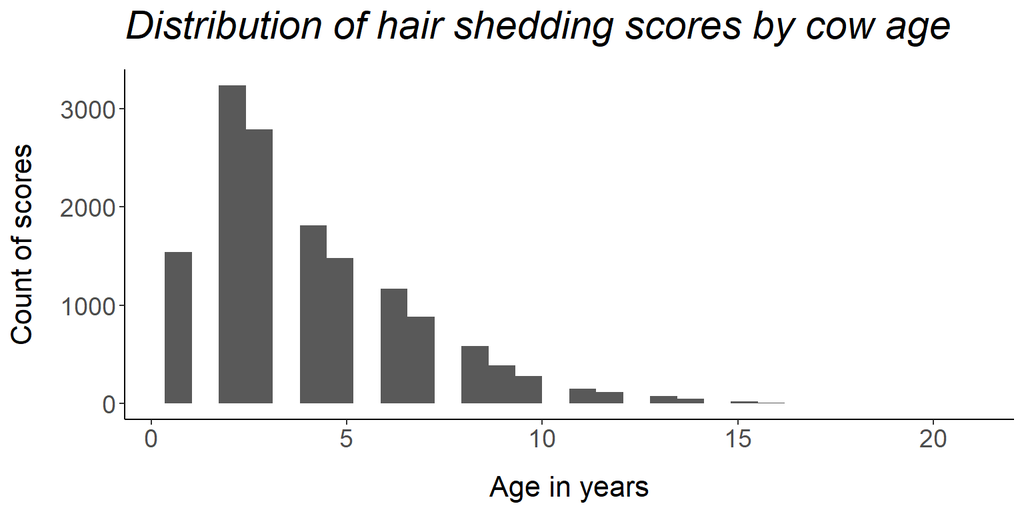

```r
age_start %>%
  ggplot(aes(x = age)) +
  geom_histogram() +
  scale_x_continuous() +
  labs(x = "Age in years", y = "Count of scores", title = "Distribution of hair shedding scores by cow age") +
    theme_classic() +
    theme(
      plot.title = element_text(
        size = 22,
        face = "italic",
        margin = margin(
          t = 0,
          r = 0,
          b = 13,
          l = 0
        )
      ),
      axis.title = element_text(size = 16),
      axis.title.y = element_text(margin = margin(
        t = 0,
        r = 13,
        b = 0,
        l = 0
      )),
      axis.title.x = element_text(margin = margin(
        t = 13,
        r = 0,
        b = 0,
        l = 0
      )),
      axis.text = element_text(size = 14),
      legend.position = "none"
    )
```

# Inform model choice by looking at effect of age in years as factor

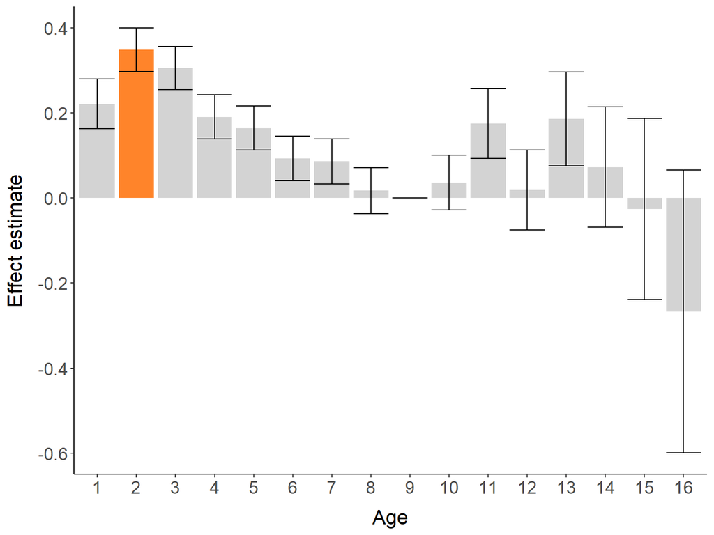

```r
# Bar plot

read_table2(
  here::here("data/derived_data/age/years_factor/solutions"),
  skip = 1,
  col_names = c("trait", "effect", "age_renamed", "solution", "se")
) %>%
  filter(effect == 2) %>%
  select(-effect, -trait) %>%
  left_join(
    parse_renf90table(
      path = here::here("data/derived_data/age/years_factor/renf90.tables"),
      effect = 2
    ) %>%
      rename(age = id_original,
             age_renamed = id_renamed)
  ) %>%
  filter(n >= 5) %>%
  arrange(age) %>%
  mutate(age = as_factor(age)) %>%
  ggplot(aes(
    x = age,
    y = solution,
    fill = ifelse(age == 2, "Highlighted", "Normal")
  )) %>%
  age_effect_theme(x_title = "Age", y_title = "Effect estimate")
```

```r
#cowplot::ggsave2("Y://agi_hairshed/figures/age.years_factor.single_step.png", width = 8, height = 6, dpi = 500)
```

```r
read_table2(
  here::here("data/derived_data/age/years_factor/solutions"),
  skip = 1,
  col_names = c("trait", "effect", "age_renamed", "solution", "se")
) %>%
  filter(effect == 2) %>%
  select(-effect, -trait) %>%
  left_join(
    parse_renf90table(
      path = here::here("data/derived_data/age/years_factor/renf90.tables"),
      effect = 2
    ) %>%
      rename(age = id_original,
             age_renamed = id_renamed)
  ) %>%
  select(age, everything(), -age_renamed) %>%
  arrange(age)
```

| age | solution | se | n |
| --- | --- | --- | --- |
| 1 | 0.22146135 | 0.05818588 | 1545 |
| 2 | 0.34875653 | 0.05151708 | 3241 |
| 3 | 0.30574125 | 0.05108197 | 2792 |
| 4 | 0.19094125 | 0.05159960 | 1813 |
| 5 | 0.16471348 | 0.05197752 | 1482 |
| 6 | 0.09326492 | 0.05246281 | 1172 |
| 7 | 0.08617541 | 0.05308327 | 886 |
| 8 | 0.01750590 | 0.05404478 | 585 |
| 9 | 0.00000000 | 0.00000000 | 390 |
| 10 | 0.03633102 | 0.06450966 | 281 |

[output cut: 6 more lines]

# Fixed effect estimates from age class models

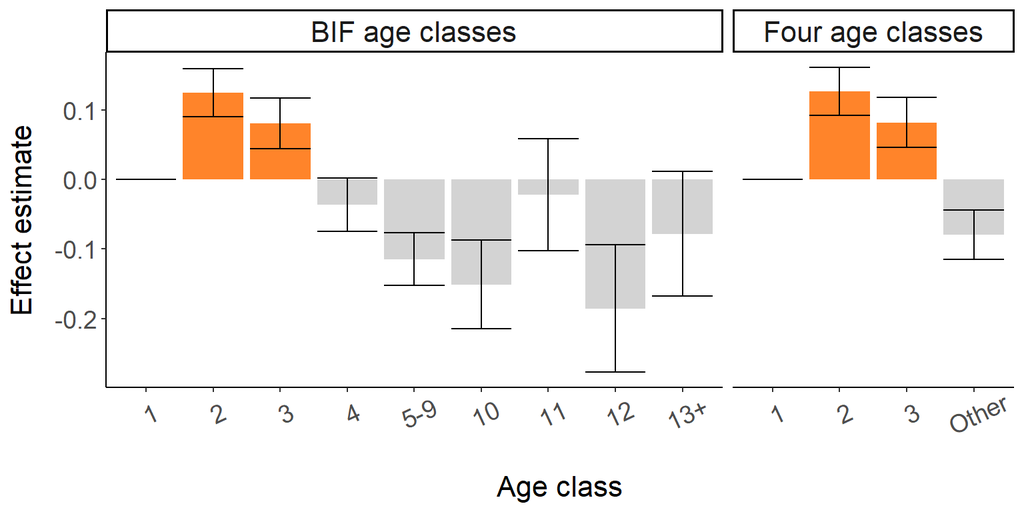

```r
  read_table2(
  here::here("data/derived_data/age/four_groups/solutions"),
  skip = 1,
  col_names = c("trait", "effect", "age_renamed", "solution", "se")
) %>%
  filter(effect == 2) %>%
  select(-effect, -trait) %>%
  left_join(
    parse_renf90table(
      path = here::here("data/derived_data/age/four_groups/renf90.tables"),
      effect = 2
    ) %>%
      rename(age = id_original,
             age_renamed = id_renamed)
  ) %>%
  mutate(mod = "Four age classes") %>%
  bind_rows(
    read_table2(
      here::here("data/derived_data/age/bif_age/solutions"),
      skip = 1,
      col_names = c("trait", "effect", "age_renamed", "solution", "se")
    ) %>%
      filter(effect == 2) %>%
      select(-effect, -trait) %>%
      left_join(
        parse_renf90table(
          path = here::here("data/derived_data/age/bif_age/renf90.tables"),
          effect = 2
        ) %>%
          rename(age = id_original,
                 age_renamed = id_renamed)
      )  %>%
      mutate(mod = "BIF age classes")
  ) %>%
  mutate(
    age = case_when(
      age == "fch" ~ "2",
      age == "yearling" ~ "1",
      age == "three" ~ "3",
      age == "four" ~ "4",
      age == "5_9" ~ "5-9",
      age == "mature" &
        mod == "Four age classes" ~ "Other",
      TRUE ~ age
    ),
    age = fct_relevel(
      as_factor(age),
      "1",
      "2",
      "3",
      "4",
      "5-9",
      "Other",
      "10",
      "11",
      "12",
      "13+"
    )
  ) %>%
  ggplot(aes(
    x = age,
    y = solution,
    fill = ifelse(solution > 0, "Highlighted", "Normal")
  )) %>%
  age_effect_theme(x_title = "Age class", y_title = "Effect estimate") +
  #facet_wrap( ~ mod, scales = "free_x", nrow = 1) +
  ggforce::facet_row(~ mod, scales = "free_x", space = "free") +
  theme(axis.text.x = element_text(angle = 25,
                                   margin = margin(
                                     t = 7,
                                     r = 3,
                                     b = 3,
                                     l = 0
                                   )),
        strip.text = element_text(size = 16))
```

```r
#ggsave("Y://agi_hairshed/figures/age.four_groups.png", width = 8, height = 6, dpi = 500)
```

# Comparison of model fit

```r
age_mods <-
  tibble(mod = c("null", "four_groups", "bif_age", "years_factor")) %>%
  mutate(AIC =
           purrr::map_dbl(
             .x = mod,
             ~ parse_loglik(
             path = here::here(glue("data/derived_data/age/{.x}/airemlf90.{.x}.log")),
             option = "AIC"
           )),
         loglik =
           purrr::map_dbl(
             .x = mod,
             ~ parse_loglik(
             path = here::here(glue("data/derived_data/age/{.x}/airemlf90.{.x}.log")),
             option = "logL"
           ))
           )
```

# Commentary

Anecdotally, we’ve observed differences between age groups in the onset of hair shedding. Particularly, first calf heifers tend to have higher hair shedding scores.  
The motivation was to:

1. Quantify the effect of age on hair shedding score
2. Determine the best strategy for age classification during contemporary grouping

Models in order of increasing complexity:

- Null (no age effect included)
- 1, 2, 3, other (four_groups)
- BIF age classes (bif_age)
- Age in years as a factor (years_factor)

The distribution of ages in the data were as follows:

```r
age_start %>%
  group_by(age) %>%
  tally() %>%
  arrange(age)
```

| age | n |
| --- | --- |
| 1 | 1545 |
| 2 | 3241 |
| 3 | 2792 |
| 4 | 1813 |
| 5 | 1482 |
| 6 | 1172 |
| 7 | 886 |
| 8 | 585 |
| 9 | 390 |
| 10 | 281 |

[output cut: 10 more lines]

To preliminarily quantify the effect of age on hair shedding score, age in years was fit as a fixed effect in a repeated records BLUP model. Age groups with fewer than 5 animals were excluded. The results of this model suggest a non-linear effect of age with larger effect sizes in yearlings, two-year-olds, & three-year-olds relative to older cows. Therefore, two increasingly complex BLUP models were fit. In the first, age was classified as 1, 2, 3, or other. In the second model, age was classified according to the guidelines set by the Beef Improvement Federation for age of dam effects on birth weight and weaning weight (2, 3, 4, 5-9, and 10+). Both models were compared against a null model with no age effect.

Models:

$$y = X_1b + X_2a + Z_1u + Z_2p + e$$

- $y$ is hair shedding score
- $b$ is contemporary group
- $a$ is age group
- $u$ is additive genetic effect
- $p$ is permanent environment effect
- $e$ is random residual

Effect size estimates were similar for both models. Both models also had lower AIC values than the null model with no age effect.

```r
age_mods %>%
  select(-loglik) %>%
  arrange(AIC)
```

| mod | AIC |
| --- | --- |
| years_factor | 38892.79 |
| four_groups | 38906.17 |
| bif_age | 38912.38 |
| null | 38983.31 |

Likelihood ratio test $-10log(p)$ values suggest a better fit of the four class model over the null ($-10log(p)$ = 8.8986182) and no improvement in model fit using BIF age classes over four age classes ($-10log(p)$ = 0)

```r
lrt_calc(
  ll_null =
    age_mods %>%
    filter(mod == "null") %>%
    pull(loglik),
  ll_test =
    age_mods %>%
    filter(mod == "four_groups") %>%
    pull(loglik)
)
```

```
## [1] 8.898618
```

```r
lrt_calc(
  ll_null =
    age_mods %>%
    filter(mod == "four_groups") %>%
    pull(loglik),
  ll_test =
    age_mods %>%
    filter(mod == "bif_age") %>%
    pull(loglik)
)
```

```
## [1] 0
```

```r
p1 <-
  read_table2(
    here::here("data/derived_data/age/years_factor/solutions"),
    skip = 1,
    col_names = c("trait", "effect", "age_renamed", "solution", "se")
  ) %>%
  filter(effect == 2) %>%
  select(-effect,-trait) %>%
  left_join(
    parse_renf90table(
      path = here::here("data/derived_data/age/years_factor/renf90.tables"),
      effect = 2
    ) %>%
      rename(age = id_original,
             age_renamed = id_renamed)
  ) %>%
  filter(n >= 5) %>%
  arrange(age) %>%
  mutate(age = as_factor(age)) %>%
  ggplot(aes(
    x = age,
    y = solution,
    fill = ifelse(solution > 0, "Highlighted", "Normal")
  )) +
  geom_bar(stat = "identity",
           position = "identity") +
  scale_fill_manual(name = "age",
                    values = c("#FF842A", "lightgrey")) +
  geom_errorbar(aes(ymin = solution - se,
                    ymax = solution + se),
                size = 0.25) +
  theme_classic() +
  theme(
    plot.title = element_blank(),
    axis.title = element_text(size = 8),
    axis.title.y = element_text(margin = margin(
      t = 0,
      r = 3,
      b = 0,
      l = 0
    )),
    axis.title.x = element_blank(),
    axis.text = element_text(size = 6),
    legend.position = "none",
    plot.margin = margin(
      t = 0.175,
      r = 0,
      b = 0,
      l = 0,
      unit = "mm"
    )
  ) +
  labs(x = NULL,
       y = "Effect estimate",
       title = NULL)
```

```r
# Bar plot
p2 <-
  read_table2(
    here::here("data/derived_data/age/four_groups/solutions"),
    skip = 1,
    col_names = c("trait", "effect", "age_renamed", "solution", "se")
  ) %>%
  filter(effect == 2) %>%
  select(-effect,-trait) %>%
  left_join(
    parse_renf90table(
      path = here::here("data/derived_data/age/four_groups/renf90.tables"),
      effect = 2
    ) %>%
      rename(age = id_original,
             age_renamed = id_renamed)
  ) %>%
  mutate(mod = "Four age classes") %>%
  bind_rows(
    read_table2(
      here::here("data/derived_data/age/bif_age/solutions"),
      skip = 1,
      col_names = c("trait", "effect", "age_renamed", "solution", "se")
    ) %>%
      filter(effect == 2) %>%
      select(-effect,-trait) %>%
      left_join(
        parse_renf90table(
          path = here::here("data/derived_data/age/bif_age/renf90.tables"),
          effect = 2
        ) %>%
          rename(age = id_original,
                 age_renamed = id_renamed)
      )  %>%
      mutate(mod = "BIF age classes")
  ) %>%
  mutate(
    age = case_when(
      age == "fch" ~ "2",
      age == "yearling" ~ "1",
      age == "three" ~ "3",
      age == "four" ~ "4",
      age == "5_9" ~ "5-9",
      age == "mature" &
        mod == "Four age classes" ~ "Other",
      TRUE ~ age
    ),
    age = fct_relevel(
      as_factor(age),
      "1",
      "2",
      "3",
      "4",
      "5-9",
      "Other",
      "10",
      "11",
      "12",
      "13+"
    )
  ) %>%
  ggplot(aes(
    x = age,
    y = solution,
    fill = ifelse(solution > 0, "Highlighted", "Normal")
  )) +
  geom_bar(stat = "identity",
           position = "identity") +
  scale_fill_manual(name = "age",
                    values = c("#FF842A", "lightgrey")) +
  geom_errorbar(aes(ymin = solution - se,
                    ymax = solution + se),
                size = 0.25) +
  theme_classic() +
  theme(
    plot.title = element_blank(),
    axis.title = element_text(size = 8),
    axis.title.y = element_text(margin = margin(
      t = 0,
      r = 3,
      b = 0,
      l = 0
    )),
    axis.text = element_text(size = 6),
    legend.position = "none",
    plot.margin = margin(
      t = 0.175,
      r = 0,
      b = 0,
      l = 0,
      unit = "mm"
    )
  ) +
  labs(x = "Age class",
       y = "Effect estimate",
       title = NULL) +
  ggforce::facet_row( ~ mod, scales = "free_x", space = "free") +
  # Plot 2 specific stuff
  theme(
    axis.text.x = element_text(angle = 25,
                               margin = margin(
                                 t = 3,
                                 r = 3,
                                 b = 1,
                                 l = 0
                               )),
    axis.title.x = element_text(margin = margin(
      t = 0,
      r = 0,
      b = 0,
      l = 0,
      unit = "mm"
    )),
    strip.text = element_text(size = 7)
  )


#ggsave("Y://agi_hairshed/figures/age.four_groups.png", width = 8, height = 6, dpi = 500)
```

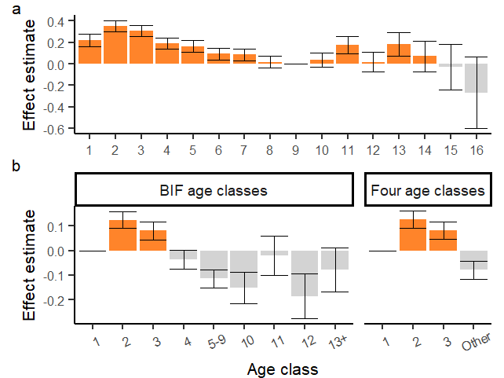

```r
p1/p2 + plot_annotation(tag_levels = c("a")) &
  theme(plot.tag = element_text(size = 8),
        plot.margin = margin(t = 0, b = 0, l = 1, r = 1, unit = "mm"))
```

```r
#ggsave("Y://agi_hairshed/figures/figure3.age_patchwork.pdf", width = 85, height = 63.75, units = "mm", dpi = 300)
```